# 为具身 Flow/VLA 模型接入 IREE 后端：从模型契约到整图编译

以 Wall-OSS-0.5 为例，拆解条件上下文、MoT 共享注意力、Flow 动作生成、静态 shape 与设备 ABI

> 先说清楚支持一个新模型时到底要改什么。**IREE 源码和 pass 均保持上游版本，我们只在 Wall-X 内增加模型支持和后端接入。** IREE 是现成的第三方编译与运行后端，我们承担的是模型适配和 上游 serving 接入工作。一次典型接入分成四层：  
> 1. **用 PyTorch 写出可导出的计算图。** 保留官方模型的算子顺序和数值语义，把动态 shape、隐式 cache、Host 控制流改成显式 tensor、静态切片和静态循环。这里写的是描述计算图的 `nn.Module`，CUDA kernel 由 IREE 或 Inductor 在后续编译中生成。  
> 2. **定义部署接口并导出。** 用 Turbine/torch-mlir 得到 Torch-level IR，把权重外置为 IRPA，固定输入 shape、输出 shape、noise、mask、时间网格和诊断入口。  
> 3. **交给官方 IREE 编译和执行。** `iree-compile` 的既有 pass 完成 linalg、Flow dispatch、Stream、HAL 和 VM lowering，`iree.runtime` 加载 VMFB/IRPA。我们使用这些标准能力，编译器本身保持原样。  
> 4. **接入 Wall-X serving 并验证。** backend 负责模型专属预处理、artifact 配置、能力检查和官方 finalizer，随后做同 noise 数值对拍、真实 serving、动作响应和 `torch.compile` 同边界对照。  
> 因此，新增模型时的主要工作量集中在**模型语义、shape/state、数值验证和 serving 集成**。遇到超出 Dynamo trace 能力的自定义 CUDA op 或动态路由时，我们用等价的可 trace 运算表达，或者把明确属于 Host 的工作留在接口外。  
> 这篇文章从一次真实动作请求讲起：Wall-X serving 收到两路图像、一条指令和机器人状态后，先形成 606 个视觉/文本/状态 prefix token，再接入 32 个 action token。模型从 `[1,32,26]` 的高斯噪声出发，经过一次 joint prefill 和 9 次 suffix/Euler，最终返回 32 个未来动作位置。我们把这段可张量化主链编译为一个 `full_flow.vmfb`，JPEG 解码、tokenizer、动态 mask 和最终反归一化仍由官方 Host 侧代码完成。  
> 阅读时只需抓住三条线。**第一条是张量怎样流动**：606/638 双段序列、36 层双 expert、K/V、DOF mask 和时间网格如何进入部署接口（deployment ABI）。**第二条是 IREE 怎样接管计算**：Torch-level IR 如何经过 input conversion、linalg、Flow dispatch、Stream、HAL 和 VM 变成 CUDA 可执行模块。**第三条是 Wall-X 怎样选择后端**：同一 serving 接口下，eager、`torch.compile` 和 IREE 如何分别执行并比较。  
> 每章都配当前分支的核心源码和实际执行记录。你会看到 `iree-compile` 自己输出的 pass statistics 和 timing、真实 `iree-expanded` 后端激活、完整动作响应，以及同 generate-call 下 `torch.compile` 137.290 ms 对 expanded 389.720 ms 的差距。严格数值结论也直接写出：最终动作通过有限门槛，context 和 V-cache 的严格结果为 FAIL，expanded 当前是 experimental-only。其他具身 Flow/VLA 可以复用这套接入顺序，具体 shape、路由、mask 和动作语义则必须从各自 checkpoint 重新确认。  
> 模型背景引用 [WALL-OSS，arXiv:2509.11766](https://arxiv.org/pdf/2509.11766) 与 [Wall-OSS-0.5，arXiv:2605.30877v2](https://arxiv.org/pdf/2605.30877v2)，页码为 PDF 页序。文中 serving 检查只看 WebSocket 返回的动作形状和有限数值，数值对拍另列与官方实现的误差，性能测试另列各后端耗时；机器人任务成功率需要独立的任务评测。当前 `iree-expanded` 的验收状态以后文真实日志为准。

**全文按四部分阅读：**

| 部分 | 章节 | 要回答的问题 |
| --- | --- | --- |
| 模型与接口 | 第 1–3 章 | 一次动作请求包含哪些计算？H/D、MoT、K/V、DOF 和时间网格怎样决定部署接口？ |
| 整图与编译 | 第 4–5 章 | Python 静态模块怎样变成 MLIR？IREE 的 input conversion、dispatch、Stream、HAL、VM 各做什么？ |
| 后端与原生证据 | 第 6–9 章 | eager、`torch.compile` 和 IREE 怎样挂到同一 Wall-X serving？真实编译、动作响应和数值验收长什么样？ |
| 性能与扩展 | 第 10–11 章 | expanded 与 `torch.compile` 差多少、差距来自哪些待测环节？新增模型或 embodiment 应按什么顺序修改？ |

## 一、接入 IREE 的起点：定义模型契约与整图边界

### 1.1 具身 Flow/VLA 后端需要接管哪些计算

许多具身 VLA 可以拆成两个逻辑阶段。第一阶段把相机图像、语言指令、机器人状态和 embodiment 配置编码为条件上下文 $c$；第二阶段从噪声动作块出发，在条件 $c$ 上反复评估速度场，得到连续动作序列：

$$ c=E(\text{images},\text{instruction},\text{state},\text{embodiment}), \qquad v_j=v_\theta(z_j,t_j,c), \qquad z_{j+1}=\mathcal S(z_j,v_j,t_j,t_{j+1}). $$

这里的 $E$ 可以包含 ViT、文本/状态嵌入和多层 Transformer，$\mathcal S$ 表示具体的 Flow solver 更新。IREE 后端接入工作要回答：哪些部分进入同一张设备计算图，哪些状态在图内复用，哪些输入由Host 侧准备，最终动作在哪一种表示下跨出 ABI。

编译器需要一份可检查的契约，至少分成四层：

| 契约层 | 需要明确的内容 | 对 IREE 接入的影响 |
| --- | --- | --- |
| 模型语义 | 条件输入、动作 horizon、动作维度、专家可见性、连续输出含义 | 决定计算是否与原模型等价 |
| 张量图 | shape、dtype、路由边界、mask、时间网格、K/V 与动作状态的生命周期 | 决定能否 trace、静态化和 lowering |
| 部署接口 | 显式输入、外置权重、返回值、生产与诊断入口 | 决定 runtime 如何加载和调用 VMFB |
| Host 侧/serving | 图像解码、tokenizer、动态 metadata、反归一化、协议和机器人配置 | 决定官方 wrapper 怎样无歧义地衔接设备图 |

这份分层也给出验证顺序：先确认语义，再核对张量与状态，随后检查设备调用，最后测量 serving 和性能。只看到一次 `main` 返回有限数值，尚不足以证明每一层契约都已满足。

### 1.2 后端无关的七个接入问题

面对一个新的具身 Flow/VLA 模型，可以先固定以下答案：

1. **输出怎样构成动作块。** 用 $H$ 表示 action horizon，用 $D$ 表示每个动作位置的特征维度，典型输出为 `[B,H,D]`。$H$ 与 $D$ 分别进入 noise、mask、投影和输出 ABI。
2. **条件怎样进入图。** 图像可能已是 patch tensor，文本和 proprioception 可能已变成 token，position 与 attention mask 也可能由Host 侧构造。每种表示都有对应的输入边界。
3. **专家怎样路由并交换信息。** token-type 路由、top-k 路由、共享 attention、独立 cross-attention 会产生不同的张量拼接、权重布局和 mask。
4. **哪些状态能够复用。** 一次请求内不变的 prefix K/V 可以缓存；随 Flow 时间变化的动作 hidden、当前 K/V 和 solver 状态需要重算或显式传递。
5. **推理采用什么时间语义。** Flow 进度、动作序列的机器人时间和设备 wall time 属于不同坐标，分别影响 solver schedule、控制配置和性能测量。
6. **哪些训练组件可以留在部署图之外。** 连续动作部署接口只包含推理所需的状态和算子。
7. **哪些维度需要静态特化。** batch、图像网格、prefix 长度、action horizon、层数和时间步数可以成为编译 profile；可变输入通过 padding、bucket 或独立导出处理。

这些答案最终都会体现在 ABI 中。动作维度决定 `[H,D]` 张量，确定性专家路由决定分段边界，共享 attention 决定联合 Q/K/V 与可见性矩阵，Flow solver 决定时间数组和循环状态，Host 侧预处理与后处理决定还需要保留哪些官方 wrapper 逻辑。

### 1.3 Wall-OSS-0.5 案例的整图边界

当前案例把可张量化的模型主链放进 `StaticFullFlow`：视觉塔、文本/图像/状态嵌入、t=0 action embedding、36 层双 expert Transformer、首次速度评估、prefix K/V、后续 9 次速度评估和 Euler 更新位于同一个 `main`。生产入口返回最终归一化动作；诊断入口另行导出中间 context、K/V、速度与轨迹。

JPEG 解码、图像 resize/normalization、tokenizer、state-string 离散化、动态 position/mask 准备、最终反归一化、msgpack 与 WebSocket 仍由Host 侧承担。生产形态使用一个 `full_flow.vmfb` 和匹配的 `full_flow.weights.irpa`，每次请求调用一次 `main`。后文将逐层检查这条边界，下面先解释它依赖的模型语义。

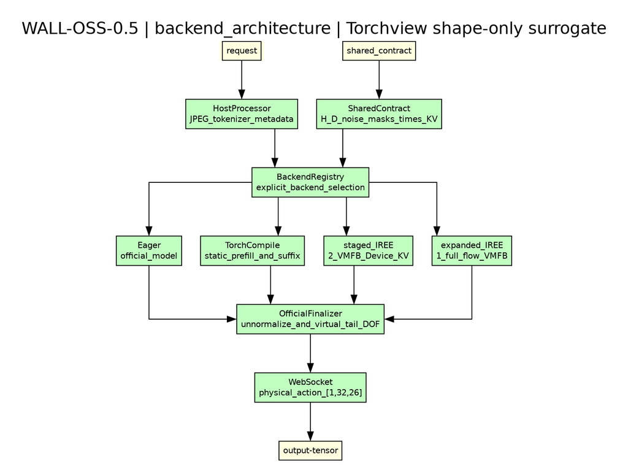

具身 Flow 模型的 Wall-X serving 后端：eager、torch.compile 与 IREE 并列

serving 层通过同一个 backend registry 选择官方 eager、`torch.compile` 或 IREE。模型支持、artifact 配置和数值验收由各后端包承担，官方 wrapper 继续提供统一的观测、协议与动作接口。

## 二、具身 Flow/VLA 的背景：动作块、训练接口与两种时间

### 2.1 Action horizon 与 action dimension 回答不同问题

动作块可以写为 $Z\in\mathbb R^{B\times H\times D}$：

- $H$ 是 **action horizon**，表示一次预测包含多少个未来动作位置；
- $D$ 是 **action dimension**，表示每个动作位置需要多少个数值来描述；
- $B$ 是 batch size，与机器人时间无关。

Wall-OSS-0.5 的论文接口预测一秒动作 horizon，帧数随数据源控制频率调整（§2.2.3，p.7）。当前导出案例实例化为 $B=1,H=32,D=26$，所以 noise、网络速度和最终归一化动作都使用 `[1,32,26]`。这里的 32 描述动作序列长度，26 描述每个位置的表达能力；Flow solver 的评估次数由 `num_inference_timesteps` 和 `times` 单独决定。

机器人执行动作块时还需要控制频率、插值和重规划策略。Flow 求解则在另一条时间轴上工作：一次动作请求可以从噪声开始，经过若干次网络评估生成全部 32 个位置。每个 Flow 时间点同时作用于整个 `[32,26]` 动作块，并不依次对应某一个机器人动作帧。

### 2.2 离散 RVQ/FAST 与连续 Flow 承担不同阶段的职责

VLA 常用离散动作 token 接入语言模型的自回归训练接口。FAST 提供规则驱动的动作压缩；Wall-OSS-0.5 改用学习得到的 Vision-Aligned RVQ Action Tokenizer，在 observation-conditioned delta action 上执行 Encoder–RVQ–Decoder 训练，并加入视觉—动作对齐、下一帧预测和 DCT 域重建目标（§2.1.2，p.5）。

在 Wall-OSS-0.5 的 gradient-bridged co-training 中：

- action-token cross-entropy 预测 RVQ token，为 VLM backbone 提供动作相关的训练梯度；
- multimodal cross-entropy 维持指令、视觉定位与具身场景理解；
- flow matching 训练连续 Action Expert，供部署时生成动作块（§2.2.1，p.5–6）。

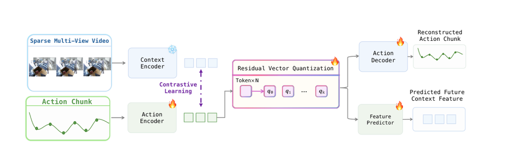

论文原图：Vision-Aligned RVQ Action Tokenizer 的 Encoder–RVQ–Decoder 训练结构，含视觉对齐、下一帧预测和动作重建目标（Wall-OSS-0.5，Figure 3，p.5）

这张图对应的是**训练时的动作表示学习**：视频和动作块分别编码，经 RVQ 得到离散 token，再训练动作重建和未来特征预测。当前 `full_flow` 只导出下方的连续 Flow Action Expert。

默认动作推理沿连续 Flow 路径解码，离散动作 token 用于训练接口（§2.2.1，p.6；§2.2.3，p.7）。因此，通用动作后端可以把 RVQ 码本、AR 解码、CE 和真值动作留在训练侧；生产图重点保留条件编码、连续动作投影、共享 Transformer、速度输出和 solver。若某个产品同时提供离散动作或文本生成入口，应把它作为独立模型契约和独立导出处理。

### 2.3 训练损失与推理计算分别定义接口

Flow Matching 的训练插值可以写成：

$$ z_t=(1-t)z_0+t\,a, \qquad v_{\text{target}}=a-z_0, $$

其中 $a$ 是真实动作，$z_0$ 是噪声。网络接收 $z_t,t,c$，学习速度场 $v_\theta(z_t,t,c)$。真实动作只在训练时提供；部署从显式或随机生成的 $z_0$ 出发，反复评估 $v_\theta$ 并更新状态。

Wall-OSS-0.5 的联合损失为

$$ \mathcal L=\mathcal L_{\text{flow}} +0.01\mathcal L_{\text{act-CE}} +0.01\mathcal L_{\text{mm-CE}} $$

（§2.2.1，p.6，式(1)）。Action-Space Supervision 保留网络的速度预测，同时在恢复动作上计算损失，并等价于速度损失的 $(1-t)^2$ 加权（§2.2.2，p.6，式(2)–(6)）。这些公式解释训练怎样塑造网络，部署接口只接收推理所需 tensor。

当前案例的 `use_x_pred=False`，`action_proj_back` 的输出直接作为速度进入 Euler 更新。训练时采用 action-space loss，运行时仍由 `action_proj_back` 直接输出速度；IREE 对拍继续逐层比较速度、状态和最终动作。

2025 年 WALL-OSS 论文在 Integration Stage 使用 $x_t=(1-\rho)x_0+\rho\epsilon$ 与目标 $\epsilon-x_0$，即从干净动作走向噪声的 $\rho$ 坐标。当前部署采用从噪声走向动作的 $t$ 坐标。令 $t=1-\rho$，速度符号随之反转，两种写法描述同一条概率路径。后端以实际代码的时间方向为准，Euler 输入使用代码中的 $t$ 网格。

### 2.4 Flow 时间、机器人时间与设备耗时

Flow 时间 $t$ 是从噪声到动作的归一化进度坐标。若使用 Euler solver，状态更新为

$$ z_{j+1}=z_j+(t_{j+1}-t_j)v_\theta(z_j,t_j,c). $$

当前案例配置 `num_inference_timesteps=10`，`get_inference_times` 产生 11 个时间点，形成 10 次速度评估和 10 次状态更新：prefill 完成第 1 次，suffix 完成后 9 次。动作状态记为 $z_0,z_1,\ldots,z_{10}$，每次更新都处理完整的 `[1,32,26]`。

`time_shift` 调整评估位置，`s` 对时间网格做整体缩放。本案例 `time_shift=1.0`、`s=0.999`，所以原始 `linspace(0,1,11)` 被缩放为 `0,0.0999,…,0.999`。训练使用的 `beta_alpha=1.5`、`beta_beta=1.0` 控制随机时间采样；推理使用固定网格，二者分别描述训练采样与部署 schedule。

这里有三套需要分别写入文档和代码的时间概念：

| 概念 | 在本案例中的体现 | 对后端的作用 |
| --- | --- | --- |
| Flow 进度 | 11 个 t_j、10 个 solver 区间 | 决定 `times[11]`、每步 timestep 与 `dt` |
| 机器人动作时间 | 32 个动作位置；论文接口为一秒 horizon，帧率随数据源配置 | 决定动作块语义、执行和重规划配置 |
| 设备 wall time | context、prefill、suffix、Host finalizer 与协议耗时 | 仅用于性能测量 |

Flow 评估次数由 solver schedule 决定，与 action horizon 和设备耗时分别定义；$t_j$ 来自时间网格。

### 2.5 $\pi_0$、$\pi_{0.5}$ 与 Wall-OSS-0.5 的边界

这些模型共享 Flow/VLA 的若干设计元素，各自契约仍需单独核对：

- Wall-OSS-0.5 的高噪声训练时间采样明确跟随 $\pi_0$：Beta 采样后经过 $1-u$ 与尺度缩放（§2.2.2，p.6，式(3)）。这是训练 schedule 的方法联系。
- $\pi_{0.5}$ 共同训练 FAST-based 自回归路径和 flow-matching 路径。Wall-OSS-0.5 使用 Vision-Aligned RVQ，把离散路径作为 gradient bridge，并加入 Action-Space Supervision（§6，p.21）。
- 报告还将 Wall-OSS-0.5 的端到端梯度与 $\pi_{0.5}$ 的 stop-gradient 设计对照（§2.2.1，p.5–6）。这个差异影响训练图，部署 ABI 应以各自实际 inference graph 为准。
- Wall-OSS-0.5 从 Qwen2.5-VL-3B-Instruct 初始化并扩展 MoT（§2.1.1，p.4），名称中的“0.5”只是版本标识，权重、shape 和 serving ABI 由各自 checkpoint 与官方实现决定。
- 2025 年 WALL-OSS 以 FAST 离散动作先验、Flow Head 和 Uni-CoT 组织训练；2026 年 Wall-OSS-0.5 改用 Vision-Aligned RVQ，并明确把离散路径作为 gradient bridge，目标是直接得到部署可用的预训练策略。两代模型的训练接口发生变化，连续 Flow 推理所要求的显式状态与动作 ABI 仍可按同一方法分析。
- 旧论文同时指出 $\pi_0$ 在部分精细操作上更强（WALL-OSS §6.1，p.14）。这些比较用于理解模型结构和计算语义，不构成“某一代模型全面优于另一系列”的依据。

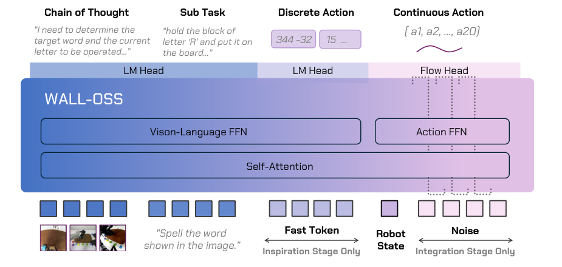

论文原图：2025 年 WALL-OSS 总体架构。VL FFN 与 Action FFN 通过 self-attention 共享序列上下文；Inspiration 阶段使用 FAST token，Integration 阶段使用 Flow Head（WALL-OSS，Figure 3，p.4）

这张原图帮助区分两代训练接口：2025 年的离散侧是 FAST token，2026 年则换成前面的 Vision-Aligned RVQ。两侧共享 attention 的基本思想延续下来，当前 IREE 案例只取连续 Flow 推理路径。

对通用 IREE 后端而言，可复用的是条件编码、显式状态和迭代求解的接入方法；模型专属 tokenizer、路由边界、action schema 与 solver 配置必须来自各自 checkpoint 和官方实现。

## 三、Wall-OSS-0.5 案例：把 MoT 与动作语义落成真实 ABI

### 3.1 MoT：两路 Expert 怎样在一条 638 行序列里协同工作

先只看一条输入序列，不谈公式。VL 是 vision-language 的缩写。当前 638 个 token 按来源分成两段：

| 序列位置 | token 内容 | 进入哪个 Expert |
| --- | --- | --- |
| `[0,512)` | 两路图像产生的 512 个视觉 token | VL Expert |
| `[512,606)` | 指令、特殊标记和离散化状态，共 94 个 | VL Expert |
| `[606,638)` | 当前带噪连续动作，共 32 个 | Action Expert |

因此，`moe_token_types = [False × 606, True × 32]` 可以直接读成一张分流表：

```
token_index < 606  → VL Expert
token_index >= 606 → Action Expert
```

路由在输入阶段已经写好，前向计算按这张表选择 Expert。后文所说的**确定性 expert routing**就是这个意思。短输入在左侧 padding 后，路由表、起止索引、position 和 mask 必须一起移动，右侧 32 个 action 始终保持在 `[606,638)`。

**第一步：两路分别做 norm 和 QKV 投影。**

每层 Transformer 先对两段分别做归一化，再分别乘各自的 QKV 权重。Q/K/V 是 query、key、value，O 是 attention 之后的输出投影，MLP 是每个 Expert 自己的前馈网络。

- VL 段输入宽度为 2048，VL Expert 的 fused QKV 输出为 2560。
- Action 段输入宽度为 1024，Action Expert 的 fused QKV 输出同样为 2560。
- 2560 都拆成 `2048 + 256 + 256`，对应 Q、K、V。于是两路都能形成 16 个 128 维 Q head 和 2 个 128 维 KV head。

两路参数各自独立，head 几何则一致。Action Expert 的 hidden 为 1024，head_dim 始终为 128。

**第二步：把 Q/K/V 拼回 638 行，做一次 joint attention。**

两路 Q/K/V 按原来的序列顺序拼接，恢复 `[VL prefix | current action]` 的 638 行布局，然后执行带 mask 的 joint attention。这里共享的是注意力计算和跨段信息交换，QKV/O/MLP 的权重仍然分属两路。

用一个 action query 就能看出 mask 的作用。当前 `causal_action_attention_mask=true`：

- 第 0 个 action query 可以看到 606 个 prefix key 和自身，共 607 个 key；
- 第 5 个 action query 可以看到 606 个 prefix key 和前 6 个当前 action key，共 612 个 key。

这样，当前连续动作可以读取图像、指令和机器人状态。离散动作与连续动作之间的可见规则由 mask 逐行确定。

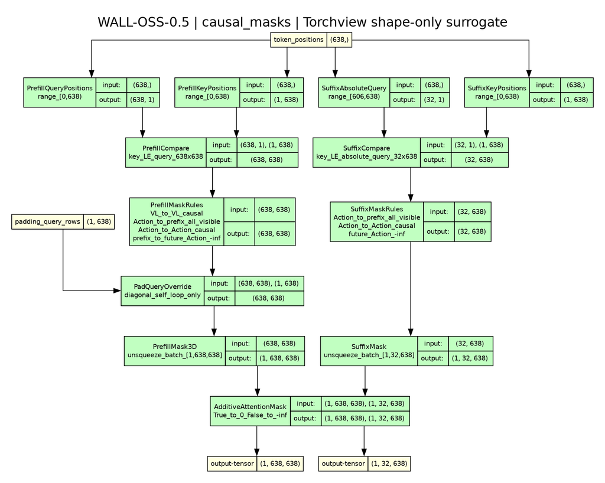

Joint self-attention 的全序列 causal mask：VL 与 Action 的可见区域、-inf 遮蔽和 suffix 的 32×638 布局

Q/K/V 都来自同一条拼接序列，因此这里的计算形式是 **joint self-attention**，与 encoder-decoder cross-attention 的独立上下文来源不同。当前 mask 由 `tril` 生成：VL prefix query 也只能读取历史 prefix，prefix 到未来 action 的区域被遮蔽。suffix 的 32 个 action query 对 638 个 key 计算时，606 个 prefix key 全部可见，当前 action 仍按 causal 下三角可见。prefill 使用 fp16-score math attention，suffix 的 `online_attention` 是实现方式，二者沿用同一份 mask 语义。

**第三步：按原分段恢复 O、MLP 和 residual。**

attention 结束后，计算结果再次按 `[0,606)` 和 `[606,638)` 切开，分别进入两路 O 投影、MLP 和 residual。Action Expert 的输出宽度为 1024，而 joint residual 需要 2048 宽布局，所以后 1024 个 hidden 通道补零，形成 zero corridor。这个补零只负责网络通道对齐，与某个动作 DOF 是否有效无关。

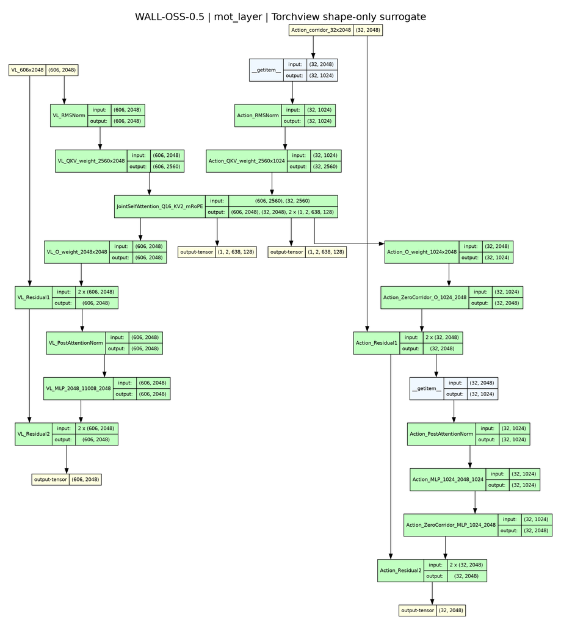

MoT 单层结构：双 Expert 独立 QKV/O/MLP、joint self-attention、zero corridor 与 K/V cache 的真实 shape

一次请求内，视觉、指令和状态保持不变，prefill 只需为 prefix 计算一次 K/V。进入下一个 Flow 时间点后，当前动作 $z_j$ 已改变，32 个 action token 的 embedding、Q/K/V 和 hidden 必须重新计算；拼接时复用的仍是前面的 606 行 prefix K/V。当前 ABI 中，36 层堆叠后的 K 或 V 为 `[36,1,2,638,128]`，prefix K 已应用 mRoPE，V 不旋转。

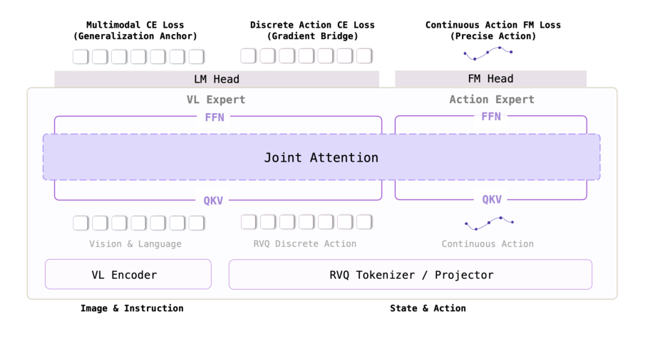

论文原图：三类训练目标与 MoT 路由。VL Expert 与 Action Expert 通过 Joint Attention 交换信息，Multimodal CE、Discrete Action CE 和 Continuous Action FM Loss 分别承担不同训练职责（Wall-OSS-0.5，Figure 2，p.4）

把论文图与上面的三步对应起来：图中的两个 FFN 是两路独立参数，贯穿两者的 Joint Attention 是信息交换位置，顶部的三项 loss 属于训练阶段。当前 IREE 部署接口只需要连续 Flow 推理路径，生产图只包含连续 Flow 推理路径。

当前 checkpoint 的主干尺寸可以压缩成下表：

| 项目 | 当前值 | 对编译的直接影响 |
| --- | --- | --- |
| 主层数 / joint hidden | 36 / 2048 | 决定层展开与 residual 布局 |
| VL Expert hidden / MLP | 2048 / 11008 | 处理视觉、文本和状态 prefix |
| Action Expert hidden / MLP | 1024 / 2048 | 处理 Flow action token |
| Attention heads | 16 Q / 2 KV / head_dim 128 | 两路 QKV 可以按统一几何拼接 |
| Action causal mask | query i 可见 prefix 与前 i+1 个当前 action | 决定 prefill 与 suffix mask |

这份结构直接决定 MLIR 中的切片、拼接和 mask：编译器必须保留 606/32 的 Expert 分段、统一 head 几何、Action causal 可见性以及 prefix K/V 的生命周期。下一节再把 606 和 638 的来源逐项展开。

### 3.2 512 + 94 = 606，606 + 32 = 638

当前 bank 使用两路 `448×448×3` 图像。checkpoint 的 `patch_size=14`、`spatial_merge_size=2`，所以每路图像先有

$$ (448/14)^2=1024 $$

个 patch，再经 2×2 spatial merge 形成 $1024/4=256$ 个 joint 视觉 token。两路合计 512 个视觉 token。加上当前指令、特殊标记与离散化状态所占的 94 个 token，得到本案例的 prefix：

```
512 个视觉 token
+ 94 个文本、特殊标记和离散化状态 token
= 606 个 prefix token
+ 32 个连续 Flow action token
= 638 个 joint sequence token
```

也就是 **512 + 94 = 606，606 + 32 = 638**。`[0,606)` 进入 VL Expert，`[606,638)` 进入 Action Expert。视觉、文本和 t=0 action embedding 合成后的 `inputs_embeds` 为 `[1,638,2048]`。

606 和 638 属于这个图像网格、指令、状态表示与 action horizon 共同确定的静态 bucket；其他配置使用各自对应的 bucket。较短输入可以在 prefix 左侧 padding，同时保持 action 位于右端；不同图像网格、超过桶长的文本或其他 horizon 需要相应 bucket 和独立数值验收。

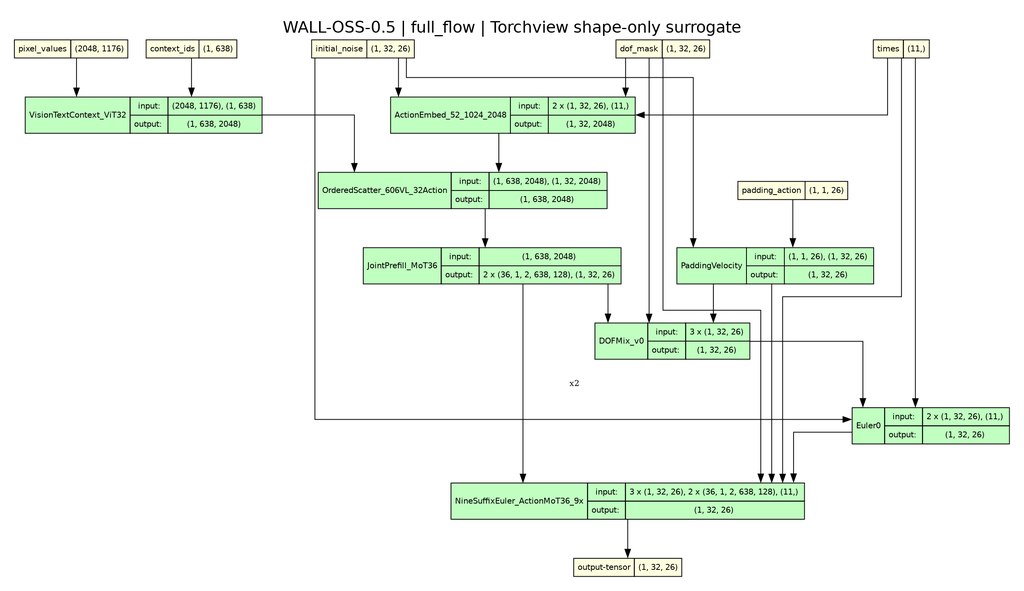

Wall-OSS-0.5 案例的模型结构、606/638 双段布局、IREE 整图边界与 1+9 Flow 时间轴

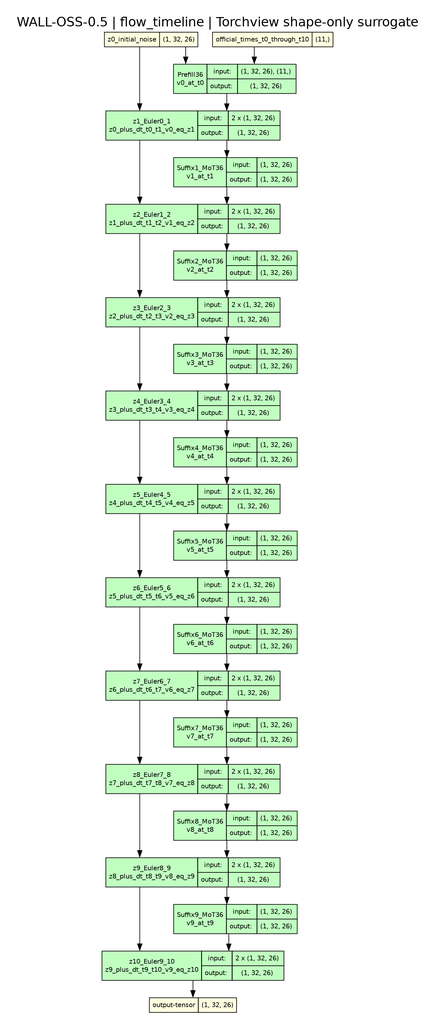

完整的 1+9 Flow 时间轴：11 个时间点、10 次速度评估和 10 次 Euler 更新

图中保留了本案例的视觉 token 计算、双段 expert 路由、整图边界与 $z_0\rightarrow z_{10}$ 状态链。时间轴进一步展开 prefill 的 `v_0` 与第一次 Euler 更新，以及随后 9 个 suffix/Euler；每个 `z_(j+1)` 都由当前 `z_j`、速度 `v_j` 和步长 `t_(j+1)-t_j` 计算，最终形成 `z_10`。后文的 MLIR 与 runtime 证据都应能回指这些张量和边界。

### 3.3 26D 动作语义与 action 分支

论文定义的模型动作空间为 26 维（§2.2.3，p.7）：

| 组成 | 维度 | 含义 |
| --- | --- | --- |
| 左、右臂各自的位置 | 每臂 3D | 相对当前末端执行器的位置变化 |
| 左、右臂各自的旋转 | 每臂 6D | 相对当前末端执行器的 6D 旋转表示 |
| 左、右夹爪 | 每臂 1D | 夹爪状态 |
| 移动底盘 | 3D | 底盘速度 |
| 升降机构 | 1D | lift 高度 |
| 头部机构 | 2D | head actuation |
| **合计** | **26D** | 双臂 $2×(3+6+1)=20$，再加 $3+1+2=6$ |

这 26 维描述每个 action horizon 位置的动作特征，与 32 个未来位置相乘后得到 `[32,26]`。网络输出先处于归一化动作空间，官方 finalizer 按 dataset/normalizer 与 DOF 配置反归一化，serving 才返回物理动作。不同 embodiment 可以复用编译主链，动作语义、normalizer 和控制映射仍需显式配置。

当前 action preprocessor 还会拼接 26 维 DOF mask：

```
noisy_action [1,32,26] + dof_mask [1,32,26]
  → concat [1,32,52]
  → 52→1024 投影，并融合 1024 维 timestep embedding
  → action hidden [1,32,1024]
  → 后补 1024 个零通道，适配 2048 维 joint residual
  → 36 层 Action Expert / joint attention
  → action_proj_back: 1024→26，输出网络速度
```

DOF mask 的 0/1 位于动作维度，zero corridor 的零位于 hidden 通道。当前 sample_000 每个动作位置有 19 个有效维度和 7 个无效维度，张量仍保留完整 26D，保证 ABI shape 稳定。

无效 DOF 使用官方参考动作构造固定速度：

$$ v_{\text{padding}}=\text{padding\_action}-\text{initial\_noise}, \qquad v=v_{\text{padding}}(1-\text{dof\_mask})+v_\theta\,\text{dof\_mask}. $$

`initial_noise` 在第一步固定后，后续 9 步继续复用同一份 `v_padding`。因此 `noise`、`padding_action` 和 `dof_mask` 都由部署接口显式提供，solver 只读取这些语义输入。

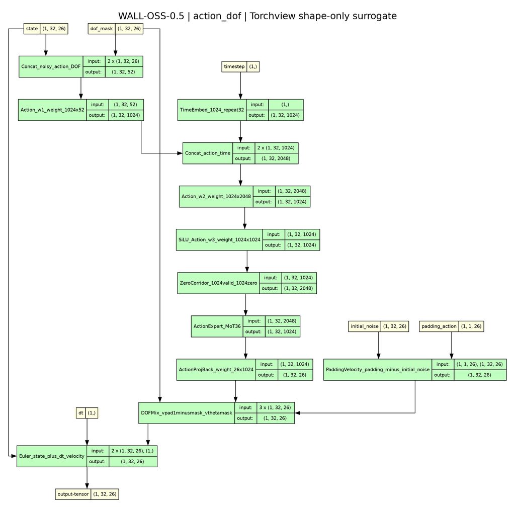

Action 分支的 52→1024→2048 布局、zero corridor、DOF 速度混合与 Euler 更新

### 3.4 从模型语义到十输入部署接口

前述背景现在可以逐项映射为当前 state-string `full_flow` 的部署接口：

| 语义决定 | 当前 ABI 表现 |
| --- | --- |
| 两路 448 图像、512 视觉 token | `pixel_values [2048,1176] f32` |
| 606/638 双段序列 | `input_ids [1,638] i64`、`position_ids [3,1,638] i64`、`mask3d [1,638,638] bool` |
| H=32、D=26 的 Flow 状态 | `noise [1,32,26] f32` |
| 26D 无效维度的官方参考动作 | `padding_action [1,1,26] f32` |
| 10 个 solver 区间、11 个 Flow 时间点 | `times [11] f32` |
| suffix 的 32 个当前 action query | `postfix_pos [3,1,32] i64`、`suffix_mask [1,32,638] bool` |
| 动作有效性与速度混合 | `dof_mask [1,32,26] f32` |

十个输入按当前导出顺序写全为：

```
input_ids      [1,638]      i64
pixel_values   [2048,1176]  f32
position_ids   [3,1,638]    i64
mask3d         [1,638,638]  bool
noise          [1,32,26]    f32
padding_action [1,1,26]     f32
times          [11]         f32
postfix_pos    [3,1,32]     i64
suffix_mask    [1,32,638]   bool
dof_mask       [1,32,26]    f32
```

生产 `main` 只返回 `z_10 [1,32,26] f32`。36 层 prefix K/V、每步速度和中间轨迹在图内传递；`full_flow_trace` 使用独立诊断接口 读取这些中间结果。Host 侧接收生产输出后执行官方反归一化。这份部署接口只包含推理输入。

这份签名同时解释了通用接入方法的复用边界：替换模型时，条件编码与 solver 的编译流程可以保留；图像网格、prefix bucket、专家分段、H/D、DOF、mask、时间网格和 finalizer 必须重新核对。adapter 必须把 checkpoint 语义完整翻译成上述显式契约。

第 4、5 章将用完整导出日志、IREE 原生编译日志和真实 `@main` 调用逐项核验这份模型契约。

下一章将沿这份契约阅读 `StaticFullFlow`：先看 context 与 t=0 embedding 怎样形成 638 行输入，再看 prefill 如何产生首步速度和可复用 K/V，最后看 9 次 suffix/Euler 如何在同一生产图中得到 `z_10`。

## 四、整图实现：StaticFullFlow 的静态模块与设备 ABI

`StaticFullFlow` 由三类计算节点组成：`StaticVisionTextContext` 构造完整序列，`StaticJointPrefill` 计算首次速度和共享 K/V，`StaticDenoiseEulerLoop` 完成后续 9 次速度与状态更新。生产 artifact 只有一个 `main`、一个 VMFB 和一个匹配的 IRPA；诊断用的 `full_flow_trace` 是另一份导出。

### 4.1 视觉与文本/状态上下文怎样进入图

`wall_x/serving/backend/static_flow/vision.py` 保留官方 ViT 的 patch embedding、32 个 block、window/full attention、RoPE、merger 和逆重排。当前静态 profile 是 2048 个 patch、32 个 64-token window、两个 1024-token full-attention segment，最后得到 512 个 merged feature。metadata 在构造模块时一次性计算，forward 只使用静态 tensor 运算；动态 window 形状直接报错。

`window_index`、`reverse_index` 和 ViT block 结构确定了静态拓扑，rotary 常量的生成设备则确定数值来源。`build_vision_profile` 在 `visual.rotary_pos_emb.inv_freq.device` 上生成并索引三角函数表，再注册为 `vision_cos/vision_sin` buffer，使静态视觉链与官方 CUDA forward 使用同设备常量。相同设备下，官方 eager 与静态 eager 的 32 层 block、merger 和最终特征均 `relmax=0.0`。整图适配因此同时固定算子顺序、常量设备和数值来源。

当前整图 serving 选择官方支持的 `WALLX_VISION_ATTN_IMPLEMENTATION=eager` 作为严格数值对齐配置，使用与官方 eager 相同的 QK、mask、fp32 softmax 和 PV 顺序，使 ViT attention 的每个阶段都可 trace 并逐项对照。核心源码保持下面的顺序，窗口或 full-attention segment 只在外层做静态分批：

```python
scores = torch.matmul(q, k.transpose(-1, -2)) / math.sqrt(self.head_dim)
probabilities = torch.softmax(scores, dim=-1, dtype=torch.float32).to(q.dtype)
return torch.matmul(probabilities, v)
```

官方 SDPA 与 FlashAttention2 仍可作为独立对照，它们与 eager 的输出差异必须单独测量；eager 对齐结论仅适用于 eager profile。

文本和状态 token 通过官方 `embed_tokens` 进入图，图像特征再按原顺序写回 `<|image_pad|>` 位置。关键的静态 scatter 用 `cumsum` 计算目标位置，避免动态 `masked_scatter` 的输出形状：

```python
base = self.embed_tokens(input_ids)
image_features = self.vision(pixel_values)
image_mask = input_ids == self.image_token_id
return _ordered_scatter(base, image_mask, image_features)

# _ordered_scatter 的核心
rank = mask.to(torch.int64).cumsum(dim=1) - 1
rank = rank.clamp(min=0, max=n - 1).reshape(-1)
gathered = values.reshape(n, -1)[rank].reshape(base.shape)
return torch.where(mask.unsqueeze(-1), gathered.to(base.dtype), base)
```

当前 checkpoint 的 `use_state_string_representation=true`，所以 proprioception 已在 Host 被离散化成文本 token；图内因此直接使用 `embed_tokens` 处理这些状态 token。对其它配置，`StaticVisionTextStateContext` 另提供显式 tensor-state ABI，并执行独立导出与验证。

### 4.2 `StaticFullFlow`：把 t=0、prefill 和 solver 串成一个 main

`wall_x/serving/backend/static_flow/full.py` 的 `_execute` 是整图的主干。它先在图内计算 t=0 action embedding，再经过 prefill 得到 K/V 和第一次 Euler 状态，最后把同一组 K/V 和 `v_padding` 传给 solver：

```python
action_embed, _ = self.ap.step(
    timestep=times[0].reshape(1), noisy_action=noise, dof_mask=dof_mask)
action_embed = action_embed.reshape(-1, context_features.shape[-1]) \
    .to(context_features.dtype)
action_mask = input_ids == self.action_token_id
embeds = _ordered_scatter(context_features, action_mask, action_embed)

k, v, v0, x0 = self.prefill(
    embeds.float(), position_ids, mask3d, noise, padding_action,
    (times[1] - times[0]).reshape(1), dof_mask=dof_mask)
v_padding = padding_action - noise
if self.TRACE:
    final, velocities, trajectory = self.solver(
        x0, times, postfix_pos, suffix_mask, k, v, v_padding,
        dof_mask=dof_mask)
    return (final, embeds.float(), k, v, v0, x0, velocities, trajectory)
final = self.solver.forward_final(
    x0, times, postfix_pos, suffix_mask, k, v, v_padding,
    dof_mask=dof_mask)
return (final,)
```

`StaticDenoiseEulerLoop.forward_final` 将后续 9 次静态展开。`times` 直接消费官方输入的 11 个时间点，保留实际的 shift、scale 和 fp32 减法顺序：

```python
x = x0
for i in range(self.num_inference_timesteps - 1):
    timestep = times[1 + i].reshape(1)
    dt = times[2 + i] - times[1 + i]
    velocity = self.step(
        x, timestep, postfix_pos, suffix_mask,
        k_past_f32, v_past_f32, v_padding=v_padding,
        dof_mask=dof_mask)
    x = x + dt * velocity
return x
```

生产 `_execute` 调用 `forward_final` 并只返回 final，因此 `main` 只有一个 `[1,32,26]f32` 输出。诊断分支调用带 `velocities` 与 `trajectory` stack 的 `forward`，由独立的 `StaticFullFlowTrace` 导出 final、embeds、K/V、v0、x0、9 个速度和 10 个状态。两种路径的最终物理动作已经逐位一致。

### 4.3 36 层主链的数值顺序与 KV ABI

`StaticJointPrefill` 逐层保留官方的 expert-wise norm、QKV/O 投影、MLP、共享 attention head、mRoPE 和 final norm。Q/K/V 拼接后统一升到 fp32，复刻官方 permute/unpermute 路径的 dtype 行为；prefix cache 存 post-rope K，V 保持原值。attention mask 来自官方 `update_joint_attention_mask_2d`，并保留 pad query 的对角自可见处理。

部署 artifact 使用 fp16-score math attention。QK 输入和 score 物化使用 fp16，MMA 累加保持 fp32，mask 加法后转 fp32 做 softmax，PV 使用 `vf.dtype`：

```python
qf16 = qf.to(torch.float16)
kf16 = kf.to(torch.float16)
add_mask = torch.where(mask4[:, 0], 0.0, float("-inf")) \
    .to(torch.float16).unsqueeze(1)
sc = torch.matmul(qf16, kf16.transpose(-1, -2)) * (128 ** -0.5)
sc = sc + add_mask
p = torch.softmax(sc.to(torch.float32), dim=-1).to(vf.dtype)
attn = torch.matmul(p, vf)
```

suffix 接收完整的 `[36,1,2,638,128]` fp32 K/V，模块内部裁出 606 行 prefix，再拼当前 32 行：

```python
k_past = k_past_f32[:, :, :, :606, :]
v_past = v_past_f32[:, :, :, :606, :]
```

在整图中，这些 K/V 是 prefill 与 solver 之间的 tensor 依赖。每个 suffix 重新形成当前 action 的 32 行 K/V，prefix 的 606 行继续复用；生产 Host 不接触这组中间缓存。

### 4.4 导出、部署接口 和诊断接口

`tools/iree/export_full_flow.py` 的 state-string 输入为 10 个张量：

```
input_ids[1,638] i64 · pixel_values[2048,1176] f32
position_ids[3,1,638] · mask3d[1,638,638]
noise[1,32,26] · padding_action[1,1,26]
times[11] · postfix_pos[3,1,32] · suffix_mask[1,32,638]
dof_mask[1,32,26]
```

生产导出 `full_flow.mlir` 的 main 只有一个 `[1,32,26]f32` 输出，`--trace` 则写 `full_flow_trace.mlir`，共享同一组外置参数名。当前参考构建产物为：

| 文件 | 大小 | 用途 |
| --- | --- | --- |
| `full_flow.mlir` | 15,608,302 B | 生产整图 Torch-level IR |
| `full_flow.weights.irpa` | 8,341,872,640 B | 视觉、主链和 action head 的外置权重 |
| `full_flow.vmfb` | 3,057,029 B | `sm_120` 生产可执行模块 |

`IreeExpandedSession` 只 mmap 这一组 VMFB/IRPA，生产每次请求调用一次 `main`，并强制输出数量为 1；只有显式选择 trace VMFB 时才读取其它诊断张量。`IreeExpandedBackend` 用 `WALLX_BACKEND=iree-expanded` 接入官方 wrapper。

下面的控制台记录来自当前 clean worktree 的两次真实导出。`full-flow profile` 直接给出 2048 patches、512 merged tokens、32 个 window 和两个 1024-token full-attention segment；MLIR 与 IRPA 的字节数和 SHA-256 也在同一次执行中输出。

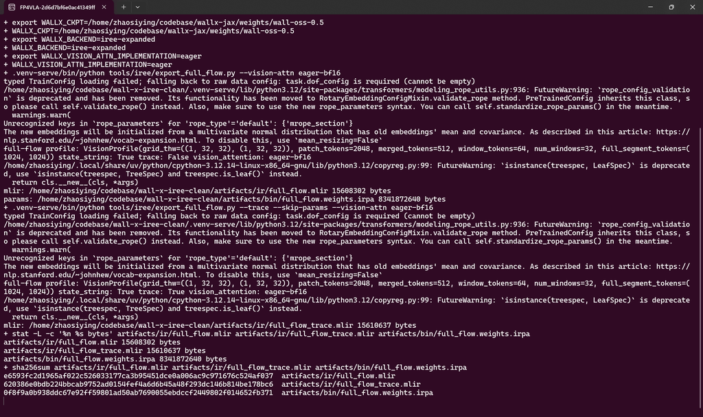

Wall-X/Turbine 生产与 trace 导出的真实控制台

**完整原生日志：implementation_evidence/native_logs/full_flow_export.console.log（5322 bytes）**

```
+ set -euo pipefail
+ set -x
+ cd /home/zhaosiying/codebase/wall-x-iree-clean
+ /usr/bin/free -g
               total        used        free      shared  buff/cache   available
Mem:              47           9          32           8          14          37
Swap:             12           8           3
+ .venv-serve/bin/python -c 'from pathlib import Path; gb=int(Path("/proc/meminfo").read_text().split("MemAvailable:")[1].split()[0])//(1024*1024); assert gb >= 16, f"available memory {gb} GB < 16 GB"'
+ nvidia-smi --query-gpu=name,memory.used,compute_cap --format=csv
name, memory.used [MiB], compute_cap
NVIDIA GeForce RTX 5090 Laptop GPU, 0 MiB, 12.0
+ export PYTHONPATH=/home/zhaosiying/codebase/wall-x-iree-clean
+ PYTHONPATH=/home/zhaosiying/codebase/wall-x-iree-clean
+ export LD_LIBRARY_PATH=/home/zhaosiying/codebase/wall-x-iree-clean/build/cudalib:
+ LD_LIBRARY_PATH=/home/zhaosiying/codebase/wall-x-iree-clean/build/cudalib:
+ export WALLX_CKPT=/home/zhaosiying/codebase/wallx-jax/weights/wall-oss-0.5
+ WALLX_CKPT=/home/zhaosiying/codebase/wallx-jax/weights/wall-oss-0.5
+ export WALLX_BACKEND=iree-expanded
+ WALLX_BACKEND=iree-expanded
+ export WALLX_VISION_ATTN_IMPLEMENTATION=eager
+ WALLX_VISION_ATTN_IMPLEMENTATION=eager
+ .venv-serve/bin/python tools/iree/export_full_flow.py --vision-attn eager-bf16
typed TrainConfig loading failed; falling back to raw data config: task.dof_config is required (cannot be empty)
/home/zhaosiying/codebase/wall-x-iree-clean/.venv-serve/lib/python3.12/site-packages/transformers/modeling_rope_utils.py:936: FutureWarning: `rope_config_validation` is deprecated and has been removed. Its functionality has been moved to RotaryEmbeddingConfigMixin.validate_rope method. PreTrainedConfig inherits this class, so please call self.validate_rope() instead. Also, make sure to use the new rope_parameters syntax. You can call self.standardize_rope_params() in the meantime.
  warnings.warn(
Unrecognized keys in `rope_parameters` for 'rope_type'='default': {'mrope_section'}
The new embeddings will be initialized from a multivariate normal distribution that has old embeddings' mean and covariance. As described in this article: https://nlp.stanford.edu/~johnhew/vocab-expansion.html. To disable this, use `mean_resizing=False`
full-flow profile: VisionProfile(grid_thw=((1, 32, 32), (1, 32, 32)), patch_tokens=2048, merged_tokens=512, window_tokens=64, num_windows=32, full_segment_tokens=(1024, 1024)) state_string: True trace: False vision_attention: eager-bf16
/home/zhaosiying/.local/share/uv/python/cpython-3.12.14-linux-x86_64-gnu/lib/python3.12/copyreg.py:99: FutureWarning: `isinstance(treespec, LeafSpec)` is deprecated, use `isinstance(treespec, TreeSpec) and treespec.is_leaf()` instead.
  return cls.__new__(cls, *args)
mlir: /home/zhaosiying/codebase/wall-x-iree-clean/artifacts/ir/full_flow.mlir 15608302 bytes
params: /home/zhaosiying/codebase/wall-x-iree-clean/artifacts/bin/full_flow.weights.irpa 8341872640 bytes
+ .venv-serve/bin/python tools/iree/export_full_flow.py --trace --skip-params --vision-attn eager-bf16
typed TrainConfig loading failed; falling back to raw data config: task.dof_config is required (cannot be empty)
/home/zhaosiying/codebase/wall-x-iree-clean/.venv-serve/lib/python3.12/site-packages/transformers/modeling_rope_utils.py:936: FutureWarning: `rope_config_validation` is deprecated and has been removed. Its functionality has been moved to RotaryEmbeddingConfigMixin.validate_rope method. PreTrainedConfig inherits this class, so please call self.validate_rope() instead. Also, make sure to use the new rope_parameters syntax. You can call self.standardize_rope_params() in the meantime.
  warnings.warn(
Unrecognized keys in `rope_parameters` for 'rope_type'='default': {'mrope_section'}
The new embeddings will be initialized from a multivariate normal distribution that has old embeddings' mean and covariance. As described in this article: https://nlp.stanford.edu/~johnhew/vocab-expansion.html. To disable this, use `mean_resizing=False`
full-flow profile: VisionProfile(grid_thw=((1, 32, 32), (1, 32, 32)), patch_tokens=2048, merged_tokens=512, window_tokens=64, num_windows=32, full_segment_tokens=(1024, 1024)) state_string: True trace: True vision_attention: eager-bf16
/home/zhaosiying/.local/share/uv/python/cpython-3.12.14-linux-x86_64-gnu/lib/python3.12/copyreg.py:99: FutureWarning: `isinstance(treespec, LeafSpec)` is deprecated, use `isinstance(treespec, TreeSpec) and treespec.is_leaf()` instead.
  return cls.__new__(cls, *args)
mlir: /home/zhaosiying/codebase/wall-x-iree-clean/artifacts/ir/full_flow_trace.mlir 15610637 bytes
+ stat -L -c '%n %s bytes' artifacts/ir/full_flow.mlir artifacts/ir/full_flow_trace.mlir artifacts/bin/full_flow.weights.irpa
artifacts/ir/full_flow.mlir 15608302 bytes
artifacts/ir/full_flow_trace.mlir 15610637 bytes
artifacts/bin/full_flow.weights.irpa 8341872640 bytes
+ sha256sum artifacts/ir/full_flow.mlir artifacts/ir/full_flow_trace.mlir artifacts/bin/full_flow.weights.irpa
e6593fc2d1965af022c526033177ca3b95451dce0a006ac9c971676c524af037  artifacts/ir/full_flow.mlir
620386e0bdb224bbcab9752ad0154fef4a6d6b45a48f293dc146b814be178bc6  artifacts/ir/full_flow_trace.mlir
0f8f9a0b938ddc67e92ff59801ad50ab7690055ebdccf2449802f014652fb371  artifacts/bin/full_flow.weights.irpa
```

### 4.5 整图之外仍需保留的Host 侧操作

“整图”覆盖完整的可张量化模型计算图，Host 侧程序通过 ABI 与图协作。当前 ABI 外仍有 JPEG 解码、图像 resize/normalization、tokenizer、state-string 量化、`grid_thw` 和 3D position/mask 构造、noise 生成、最终反归一化、msgpack 和 WebSocket。`position_ids` 与 mask 是图的显式输入；Host 的验证计数确认 `pytorch_vision_calls=0`、`pytorch_action_step_calls=0`。

## 五、MLIR/IREE：从静态 PyTorch 图到设备执行

前文定义的张量契约和静态模块构成编译器接收的输入。接入新模型时，Python 侧的改写与 MLIR pass 是两层工作：改写负责把动态、隐式、依赖Host 侧状态的计算表达成明确的 tensor graph；IREE 的既有 pass 再负责转换、分派、设备资源配置和 CUDA 代码生成。本项目使用默认编译管线，图生效的证据来自真实阶段 IR、dispatch、runtime 调用和数值对拍。

### 5.1 整图导出与参数外置

`tools/iree/export_full_flow.py` 先按 checkpoint 的 state-string/tensor-state 配置选择 `StaticFullFlow` 或对应 trace 类，再注册外置参数并构造十个生产输入。核心顺序为：

```python
module_cls = StaticFullFlowTrace if args.trace else StaticFullFlow
module = module_cls(
    model, bank["image_grid_thw"], dof_mask=bank["ctx"]["dof_mask"],
    vision_attention=args.vision_attn).cpu().eval()

externalize_module_parameters(module)
example = [
    bank["input_ids"].cpu(),
    bank["pixel_values"].cpu().float(),
    bank["ctx"]["position_ids"].cpu(),
    mask3d,
    bank["noise"].cpu().float(),
    bank["ctx"]["padding_action"].cpu().float().reshape(1, 1, -1),
    bank["ctx"]["times"].cpu().float(),
    bank["postfix"]["position_ids"].cpu(),
    bank["postfix"]["attention_mask"].cpu().bool(),
    dof,
]
exported = export(module, *example)
exported.save_mlir(ir_out)
save_module_parameters(args.params_out, module)
```

`externalize_module_parameters` 是 Turbine 的 Python 辅助函数，给参数和 persistent buffer 加上外置标记；`export` 负责 tracing 和 FX import，保存 Torch-level IR。`save_module_parameters` 将真实权重写入 IRPA，`iree-compile` 再生成 `sm_120` VMFB。权重因此可以独立校验和替换，外置机制避免在 trace 中复制数 GB 常量。

真实 `full_flow.mlir` 的 `@main` 具有十个输入，类型依次对应 `[1,638]si64`、`[2048,1176]f32`、`[3,1,638]si64`、`[1,638,638]i1`、`[1,32,26]f32`、`[1,1,26]f32`、`[11]f32`、`[3,1,32]si64`、`[1,32,638]i1` 和 `[1,32,26]f32`。`#flow.parameter.named<"model"::...>` 将权重引用绑定到 IRPA 的 `model` scope。完整签名和逐行证据见 `implementation_evidence/ir/full_flow/torch_main.txt`。

### 5.2 与本实现直接相关的 pass 和阶段

下面的名称来自默认输入转换管线和 `full_flow` 的真实阶段 IR。它们说明编译器怎样接收已经写好的整图，并依次形成 tensor/linalg、dispatch、设备资源和 VM 调用。

| 证据中的 pass / 阶段 | 在本次接入中的具体作用 |
| --- | --- |
| `AutoInputConversionPipelinePass` | 属于 IREE 默认输入转换管线，把 Torch/FX 图送入 tensor/linalg 表示。 |
| `ConvertTorchToLinalg` 等转换 pass | 将矩阵、切片、reshape、元素计算等 Torch 语义变成可优化的 linalg/tensor 形式，保留静态 shape。 |
| `OutlineDispatchRegionsPass` | 找出可独立调度的计算区域，为后续设备 dispatch 划边界。 |
| `ConvertDispatchRegionsToWorkgroupsPass` | 把区域变成 workgroup 形式的 `flow.dispatch`，使计算可以作为设备执行单元。 |
| `DeduplicateExecutablesPass` | 合并合法的重复 executable body，避免 36 层中相同结构被无意义地重复保存。 |
| `stream` 阶段 | 将参数、外部输入和中间结果放进资源/异步依赖/timepoint 体系，形成 Host 调度与设备执行的连接。 |
| `executable-configurations` | 为各 dispatch 选择 GPU translation pipeline、workgroup/subgroup 和 lowering config。 |
| `hal` / `vm` 阶段 | 分别形成设备 buffer、executable、command buffer，以及 Host 侧 `vm.export`、`vm.call`、fence 和设备调用 ABI。 |

`full_flow` 的 Flow 阶段包含 176 个 `flow.executable` 和 10766 个 `flow.dispatch`。主函数开头已经出现 ViT patch embedding 的矩阵 dispatch，直接证明视觉塔位于同一份整图：

```
%15 = flow.dispatch @main$async_dispatch_1::@main$async_dispatch_1_matmul_2048x1280x1176_bf16xbf16xf32(%14, %11) : (tensor<2048x1176xbf16>, tensor<1280x1176xbf16>) -> tensor<2048x1280xbf16>
%19 = flow.dispatch @main$async_dispatch_3::@main$async_dispatch_3_reduction_2048x1280_f32(%18, %__parameter_model_context_vision_blocks_0_norm1_weight_tensor_1280xbf16) : (tensor<2048x1280xbf16>, tensor<1280xbf16>) -> tensor<2048x1280xbf16>
%20 = flow.dispatch @main$async_dispatch_4::@main$async_dispatch_4_matmul_2048x3840x1280_bf16xbf16xf32(%19, %__parameter_model_context_vision_blocks_0_attn_qkv_weight_tensor_3840x1280xbf16) : (tensor<2048x1280xbf16>, tensor<3840x1280xbf16>) -> tensor<2048x3840xbf16>
```

`2048×1176→2048×1280` 对应 patch projection，随后的 norm 与 `2048×1280→2048×3840` 对应视觉 block 的 fused QKV。`flow.executable` 将这些工作包装成可导出的执行单元；Stream 阶段再建立 `stream.binding.subspan`、异步资源和 `stream.cmd.dispatch`。

### 5.3 attention 在 full_flow 中的真实 lowering

`full_flow` 的 input 阶段包含 324 处 `iree_linalg_ext.attention`。suffix 的一处真实形态为：

```
%5562 = iree_linalg_ext.attention <indexing_maps = [#map24, #map25, #map26, #map27, #map28, #map29]> ins(%collapsed_3437, %collapsed_3438, %collapsed_3439, %cst, %collapsed_3440 : tensor<16x32x128xbf16>, tensor<16x638x128xbf16>, tensor<16x638x128xbf16>, f32, tensor<16x32x638xi1>) outs(%5561 : tensor<16x32x128xbf16>)
```

这里 `32` 是 suffix query 数，`638` 是 key 数，`128` 是 head dimension。到 `executable-configurations` 阶段，相关 dispatch 变为 `iree_linalg_ext.online_attention`，同时产生输出、running max 和 running sum。以下省略 lowering 属性，保留实际输入输出结构：

```
%24:3 = iree_linalg_ext.online_attention <...>
  ins(%q, %k, %v, %scale, %mask : ...)
  outs(%out, %max, %sum : tensor<...xf32>, tensor<...xf32>, tensor<...xf32>)
```

`online` 将 softmax 的归一化状态随 attention 分块处理，减少完整 score 矩阵的物化压力。部署的 fp16 math-prefill 采用显式 QK matmul、fp32 softmax 和 PV matmul；suffix 的 `online_attention` 证据只用于对应的 suffix dispatch。生产编译使用 IREE 内置 attention lowering 与默认 pass pipeline。

### 5.4 Flow、Stream、HAL、VM 各自由谁接管

```
Torch-level IR
  → input conversion / linalg
  → flow.dispatch / flow.executable
  → stream resource + async timepoint + cmd dispatch
  → configured HAL executable / CUDA translation
  → vm.export + host fence/device calls
```

`executable-configurations` 中的 `#iree_gpu.pipeline<TileAndFuse>`、`Distribute`、`VectorDistribute` 均为 IREE 内置 GPU 翻译管线枚举。它们与 `lowering_config` 一起决定分块、workgroup/subgroup 和归约方式。

HAL/VM 的边界也可以在真实 IR 中看到：

```
vm.export @main$async attributes {iree.abi.model = "coarse-fences", iree.abi.stub}
vm.func private @main(%arg0: !vm.ref<!hal.buffer_view>, ...) {
  %ref_2 = vm.call @main$async(%arg0, ..., %ref_1)
  vm.call.variadic.yieldable @hal.fence.await(%c-1, %zero, %ref_1)
  vm.return %ref_2
}
vm.export @main attributes {iree.abi.stub}
```

这解释了 `IreeExpandedSession` 如何通过 `full_flow_mod.main(...)` 调用设备程序：VM 负责 Host ABI，HAL 负责设备执行，IRPA 参数模块负责提供权重。`full_flow` 的 VM export 接收十个 buffer view 并返回一个 buffer view；9 次 solver 已在导出时展开为图内计算，Python 每次请求只调用一次 `main`。

完整的整图阶段摘录和执行日志保存在 `implementation_evidence/ir/full_flow/`，其中 `manifest.json` 记录实际编译命令、输入输出数量、artifact 哈希和当前验收结论。

下面的 24,697 行控制台记录来自同一份生产 MLIR 的真实 `iree-compile`。命令启用了 IREE 官方的 `--mlir-timing`、`--mlir-pass-statistics`、阶段 dump 和 HAL executable configuration dump。该日志由 `iree-compile` 直接输出：开头的 `AutoInputConversionPipelinePass`、中间的 dispatch/Stream/HAL/VM pass、末尾的 `107.4352` 与 `53.4331` 两列总计都由编译器直接输出。截图展示终端末尾，链接的日志块保留完整内容。

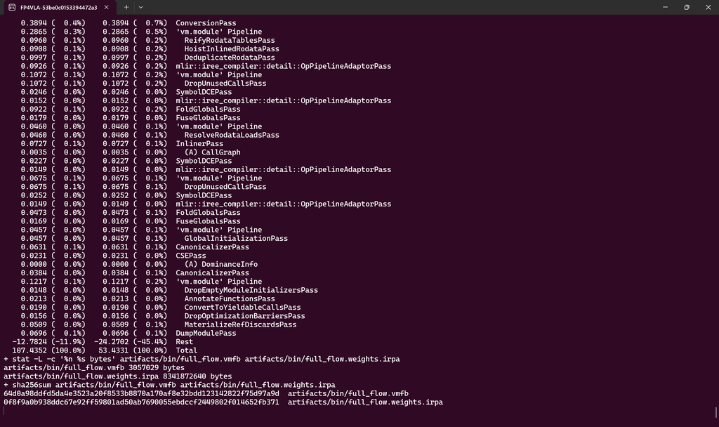

IREE 原生编译诊断与真实 artifact 哈希

**完整原生日志：implementation_evidence/native_logs/full_flow_iree_compile.console.log（1640762 bytes）**

[output not shown]

[output not shown]

[output not shown]

[output not shown]

[output not shown]

[output not shown]

[output not shown]

[output not shown]

[output not shown]

[output not shown]

[output not shown]

[output not shown]

[output not shown]

[output not shown]

[output not shown]

[output not shown]

[output not shown]